# DAtest - Two-class variable

Jakob Russel

November 2017

# Intro

This is an example of using the DAtest package for a two-class variable (same workflow as for a quantitative variable). The example uses the phyloseq package (https://joey711.github.io/phyloseq/), but a similar workflow can be used if your count-data is stored in a data.frame or matrix.

## Load packages

```r
library(phyloseq)
library(DAtest)
```

## Import

These files are downloaded from https://www.hmpdacc.org/hmp/HMQCP/

```r
otu <- import_qiime_otu_tax("v35_psn_otu.genus.fixed.txt")
map <- import_qiime_sample_data("v35_map_uniquebyPSN.txt")
```

### Create phyloseq object

```r
otu.tab <- otu_table(otu[[1]], taxa_are_rows = TRUE)
tax.tab <- tax_table(otu[[2]])
all_samples <- merge_phyloseq(otu.tab, tax.tab, map)
```

### Subset

This is just an arbitrary subset just for testing the package

```r
# Only Tongue and Saliva samples
TS <- subset_samples(all_samples, HMPbodysubsite %in% c("Tongue_dorsum","Saliva"))
# Only samples with at least 5000 reads
TS <- subset_samples(TS, sample_sums(TS) > 5000)
# Only samples from patients first visit
TS <- subset_samples(TS, visitno == 1)
# Only samples from male patients
TS <- subset_samples(TS, sex == "male")
# Only OTUs with at least 100 reads
TS <- preDA(TS, min.samples = 0, min.reads = 100, min.abundance = 0)
```

```
## 44417 features grouped as 'Others' in the output
```

## Run test

If you don’t have a phyloseq object your count data in a data.frame/matrix should be substituted for `TS` and a factor denoting the two groups should be substituted for `"HMPbodysubsite"`.

```r
test <- testDA(TS, predictor = "HMPbodysubsite")
```

```
## Seed is set to 123
```

```
## predictor is assumed to be a categorical variable with 2 levels: Saliva, Tongue_dorsum
```

#### Details from the run:

First we ensure that the function has loaded the data correctly. For example that the predictor type is as expected, and the number of samples and features are as expected.

```r
test$details
```

```
##
## Features                       967
## Samples                         75
## Predictor                Two-class
## Ordering    Saliva < Tongue_dorsum
## Paired                          No
## Covars
## RunTime              16.39 Minutes
## Relative                      TRUE
## EffectSize                       4
## Spiked     Low:10, Mid:10, High:10
## RandomSeed                     123
## OutAll                       FALSE
```

### Check results

We can plot the results:

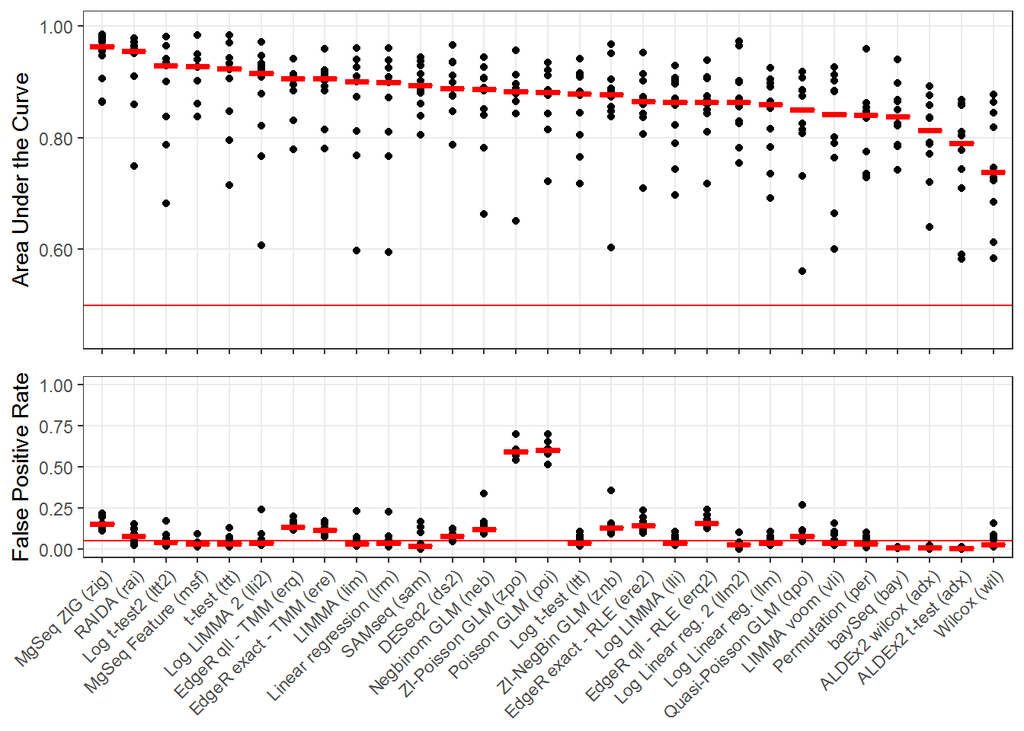

```r
plot(test)
```

A simple log t-test appears to have the highest AUC among the methods with FPR below 0.05

Lets get a summary of the results, and check out the spike detect rate (proportion spiked features with adjusted p-value < 0.05)

```r
summary(test)
```

```
##                    Method   AUC   FPR Spike.detect.rate
##           MgSeq ZIG (zig) 0.964 0.151             0.833
##               RAIDA (rai) 0.956 0.080             0.367
##        Log t-test2 (ltt2) 0.930 0.040             0.267
##       MgSeq Feature (msf) 0.927 0.032             0.350
##              t-test (ttt) 0.924 0.032             0.133
##        Log LIMMA 2 (lli2) 0.916 0.035             0.100
##   EdgeR exact - TMM (ere) 0.906 0.116             0.333
##     EdgeR qll - TMM (erq) 0.906 0.132             0.467
##               LIMMA (lim) 0.901 0.033             0.000
##   Linear regression (lrm) 0.900 0.034             0.000
##              SAMseq (sam) 0.894 0.017             0.267
##              DESeq2 (ds2) 0.888 0.077             0.333
##        Negbinom GLM (neb) 0.887 0.119             0.500
##      ZI-Poisson GLM (zpo) 0.883 0.593             0.933
##         Poisson GLM (poi) 0.881 0.602             0.950
##          Log t-test (ltt) 0.879 0.034             0.067
##       ZI-NegBin GLM (znb) 0.878 0.127             0.600
##  EdgeR exact - RLE (ere2) 0.865 0.141             0.450
##    EdgeR qll - RLE (erq2) 0.864 0.156             0.467
##           Log LIMMA (lli) 0.864 0.037             0.033
##  Log Linear reg. 2 (llm2) 0.864 0.027             0.000
##     Log Linear reg. (llm) 0.859 0.038             0.033
##   Quasi-Poisson GLM (qpo) 0.850 0.077             0.033
##          LIMMA voom (vli) 0.843 0.035             0.067
##         Permutation (per) 0.840 0.031             0.183
##              baySeq (bay) 0.839 0.007             0.000
##       ALDEx2 wilcox (adx) 0.814 0.007             0.033
##       ALDEx2 t-test (adx) 0.791 0.003             0.000
##              Wilcox (wil) 0.738 0.027             0.067
```

If your Spike.detect.rate is zero for the best method, you might want to run `testDA` again with a higher effectSize, but we would rarely expect a Spike.detect.rate above 0.500. Therefore, as long as the Spike.detect.rate is above zero for the best method we can continue.

## Run Log test 2

Log test 2 appeared to be the best method, with the highest AUC and FPR below 0.05. Lets run it with the original data to get the final results:

```r
results.ltt2 <- DA.ltt2(TS, predictor = "HMPbodysubsite")
```

results.ltt2 contains the final results

## Addtional things

### Plot association between specific feature and predictor

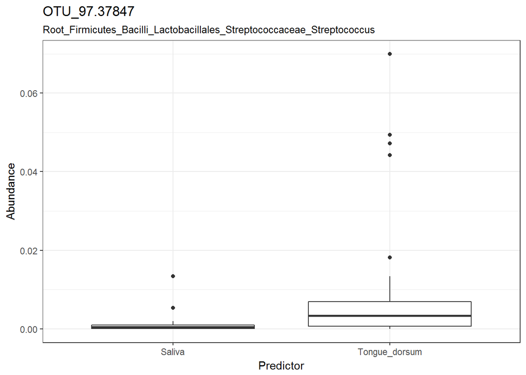

```r
# Largest effect
large.eff.feat <- results.ltt2[which.max(results.ltt2$log2FC),"Feature"]

# Plot it
featurePlot(TS, predictor = "HMPbodysubsite", feature = large.eff.feat)
```

### Test if groups of features are overrepresented among the significant features

If the features belong to certains groups, we can test if features from certain groups are more likely to be significant than features from the other groups. For microbiome data we can use a taxonomy table, and if we have a phyloseq object we simply input the tax_table and specify here to use the 2. column (Phylum) to group by. `group.df` can be any data.frame as long as it has a grouping variable and the rownames match the “Feature” column in `results`.

```r
results.group <- groupSig(results = results.ltt2, group.df = tax_table(TS), group.cols = 2)
head(results.group[order(results.group$pval.adj),])
```

```
##    GroupName          Group               Effect       OR         pval
## 2     Phylum Actinobacteria Tongue_dorsum>Saliva 4.823208 4.384443e-12
## 10    Phylum Proteobacteria Saliva>Tongue_dorsum 2.560221 1.549250e-05
## 6     Phylum     Firmicutes Tongue_dorsum>Saliva 1.522715 5.139702e-03
## 15    Phylum            TM7 Saliva>Tongue_dorsum      Inf 4.373725e-02
## 5     Phylum     Firmicutes Saliva>Tongue_dorsum 1.127236 2.723350e-01
## 9     Phylum           GN02 Saliva>Tongue_dorsum      Inf 3.530021e-01
##        pval.adj
## 2  6.576664e-11
## 10 1.161937e-04
## 6  2.569851e-02
## 15 1.640147e-01
## 5  8.170051e-01
## 9  8.825052e-01
```

Here we see that there are more significant Actinobacteria OTUs with higher abundance in Tongue than in Saliva than expected by chance.

### All tests

Lets try to run all tests and compare their results

```r
test.all <- allDA(TS, predictor = "HMPbodysubsite")
```

```
## predictor is assumed to be a categorical variable with 2 levels: Saliva, Tongue_dorsum
```

```
## Seed is set to 123
```

We can pull out results from specific methods. E.g. EdgeR exact test (ere):

```r
head(test.all$results$ere)
```

```
##                   logFC    logCPM         pval     pval.adj
## OTU_97.10006 -2.9276075  8.353264 3.048018e-06 3.135567e-05
## OTU_97.1005  -1.1375858  8.598259 1.830455e-02 3.881689e-02
## OTU_97.10201 -0.7874759  9.542233 2.005388e-01 2.978818e-01
## OTU_97.10220 -0.9474005  9.283986 8.682777e-02 1.473026e-01
## OTU_97.1030  -0.3086652  8.851373 5.817993e-01 6.809887e-01
## OTU_97.10463  0.7457615 10.215810 1.640010e-01 2.513295e-01
##                          ordering      Feature                  Method
## OTU_97.10006 Saliva>Tongue_dorsum OTU_97.10006 EdgeR exact - TMM (ere)
## OTU_97.1005  Saliva>Tongue_dorsum  OTU_97.1005 EdgeR exact - TMM (ere)
## OTU_97.10201 Saliva>Tongue_dorsum OTU_97.10201 EdgeR exact - TMM (ere)
## OTU_97.10220 Saliva>Tongue_dorsum OTU_97.10220 EdgeR exact - TMM (ere)
## OTU_97.1030  Saliva>Tongue_dorsum  OTU_97.1030 EdgeR exact - TMM (ere)
## OTU_97.10463 Tongue_dorsum>Saliva OTU_97.10463 EdgeR exact - TMM (ere)
```

#### Euler (Venn) diagrams of three select methods

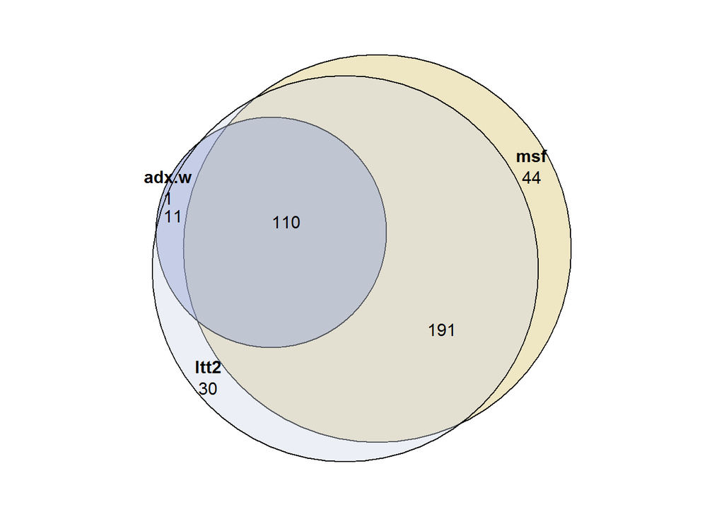

```r
vennDA(test.all, tests = c("msf","adx.w","ltt2"))
```

Split in negative and positive fold changes

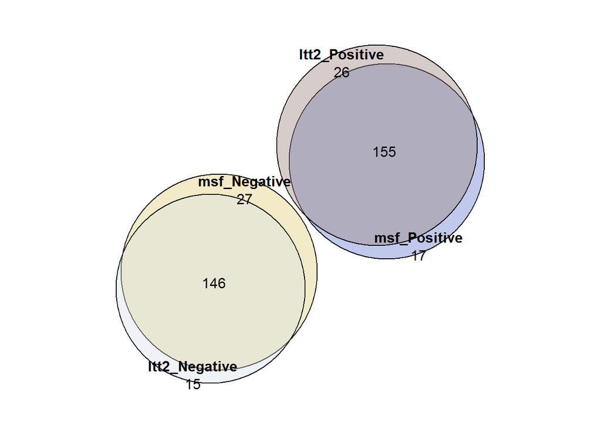

```r
vennDA(test.all, tests = c("msf","ltt2"), split = TRUE)
```